# Visualization - Scatterplots by Seaborn

In the following, we will load the "tips" dataset from the file "tips.csv". This dataset includes information from 244 receipts at a resturant. In each order, we have

- total bill amount
- tip amount
- gender of the customer
- if a customer is a smoker
- day of the order
- time of the order (dinner or lunch)
- size of dining group

```python
import pandas as pd
tips = pd.read_csv("https://raw.githubusercontent.com/zhouy185/BUS_O712/refs/heads/main/Data/tips.csv")
tips.head()
```

|  | total_bill | tip | sex | smoker | day | time | size |
| --- | --- | --- | --- | --- | --- | --- | --- |
| 0 | 16.99 | 1.01 | Female | No | Sun | Dinner | 2 |
| 1 | 10.34 | 1.66 | Male | No | Sun | Dinner | 3 |
| 2 | 21.01 | 3.50 | Male | No | Sun | Dinner | 3 |
| 3 | 23.68 | 3.31 | Male | No | Sun | Dinner | 2 |
| 4 | 24.59 | 3.61 | Female | No | Sun | Dinner | 4 |

How do we visualize the potential relationship between 'total_bill' and 'tip'?

# Scatterplots by seaborn

**seaborn** is a Python data visualization library based on matplotlib. It provides a high-level interface for drawing attractive and informative statistical graphics. With this library, one may create different types of charts.

[figure not shown]

In this notebook, we will focus on how to use seaborn to create scatterplots.

You can learn more about the library through its [documentation](https://seaborn.pydata.org/).

By default, seaborn is included in Anaconda, and we can simply import it using the `import` command. However, if you find that seaborn hasn't been installed, you may use the Anaconda Navitator, the commoand `pip install seaborn` in your command line tool (windows powershell, launchable from Anaconda Navigator, or the terminal on a Mac), or simply run `!pip install seaborn` in a cell of Jupyter.

When importing seaborn, a convention is to use the alia "sns". Since seaborn is built on top of matplotlib, it is a good practice to import pyplot from matplotlib at the same time.

```python
import seaborn as sns
import matplotlib.pyplot as plt
```

A nice feature of seaborn is its ability to work directly with a DataFrame

The basic command to create a scatterplot is

- `sns.scatterplot(data=name_of_DataFrame,x=column_a,y=column_b)`

where we can specify the dataset to work by a DataFrame

Let create a scatterplot of 'tip' vs. 'total_bill'.

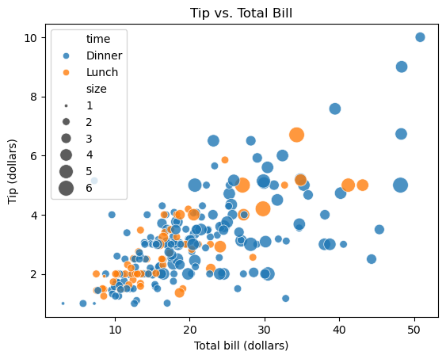

```python
sns.scatterplot(data=tips,x='total_bill',y='tip',hue='time',size='size',sizes=(10,200),alpha=0.8)

plt.title("Tip vs. Total Bill")
plt.xlabel("Total bill (dollars)")
plt.ylabel("Tip (dollars)")
plt.show()
```

Interestingly, based on a catigorical variable in the dataset, we can:

- use different colors for the points, by `hue=column_name`; e.g., use one color for all lunches, and a different color for all dinners,
- use different shapes for the points, by `style=column_name`
- use different sizes for the points, by `size=column_name`
  - the base size can be adjusted by `sizes=(min_size,max_size)`, where min_size and max_size specifies the size of the smallest point and the size of the largest point, respectively

We can use `pyplot` to add the title and labels.

You can find the arguments for `sns.scatterplot()` [here](https://www.dropbox.com/scl/fi/bsuxn9j7ab0zxb998ue9t/seaborn_parameters.pdf?rlkey=u6hyerymywoll9q78jcw3p5ze&st=id0wp1cb&dl=0).

| **Parameter** | **Description** | **Default** |
| --- | --- | --- |
| `data` | DataFrame or array-like structure (dict, array, etc.) for plotting data. | `None` |
| `x` | Variable for x-axis data (from `data` or direct). | `None` |
| `y` | Variable for y-axis data (from `data` or direct). | `None` |
| `hue` | Grouping variable to map plot colors. | `None` |
| `size` | Grouping variable to map plot sizes. | `None` |
| `style` | Grouping variable to map plot markers. | `None` |
| `palette` | Colors for the different levels of the `hue` variable. | `None` (default color cycle) |
| `hue_order` | Order of levels in `hue`. | `None` |
| `hue_norm` | Normalization range for continuous `hue`. | `None` |
| `sizes` | Mapping from `size` values to point sizes (tuple, dict, etc.). | `None` |
| `size_order` | Order of levels in `size`. | `None` |
| `size_norm` | Normalization range for continuous `size`. | `None` |
| `markers` | Marker styles for the levels of `style`. | `None` |
| `style_order` | Order of levels in `style`. | `None` |
| `legend` | How to draw the legend (`"auto"`, `"brief"`, `"full"`, `False`). | `"auto"` |
| `ax` | Axes object to draw the plot onto. | `None` (creates new axes) |
| `cmap` | Colormap for mapping the `hue` values (if continuous). | `None` |
| `linewidth` | Width of the lines around the markers. | `None` (default width) |
| `edgecolor` | Color for marker edges. | `None` (default behavior) |
| `alpha` | Transparency level for the markers (0: fully transparent, 1: fully opaque). | `None` (fully opaque) |
| `x_bins` | Bin values on the x-axis for plotting discrete data as scatterplot. | `None` |
| `y_bins` | Bin values on the y-axis for plotting discrete data as scatterplot. | `None` |
| `units` | Grouping variable to map plot styles independently of color and size. | `None` |
| `estimator` | Statistical function used to estimate the point estimate for scatter plots with continuous variables. | `None` |
| `ci` | Confidence interval used when plotting with an estimator. | `None` (no interval) |
| `n_boot` | Number of bootstrap iterations to determine confidence interval. | `None` |
| `sort` | Sort points by hue before plotting. | `True` |
| `err_style` | Style of error bars (`"band"` or `"bars"`). | `"band"` |
| `err_kws` | Keyword arguments for the error bar plot customization. | `None` |
| `log_scale` | Apply logarithmic scaling to axes (`x`, `y`, or both). | `False` |

We can add a trend line to visualize how the two variables are correlated with each other.

To do this, we will use the `regplot()` function in `seaborn` instead of `scatterplot`.

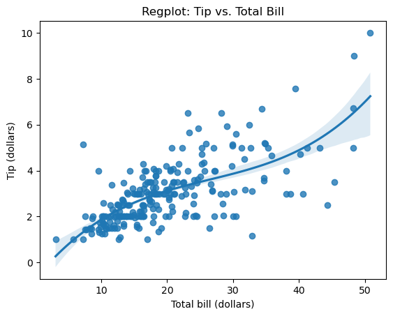

```python
sns.regplot(data=tips,x='total_bill',y='tip',order=3,ci=70)

plt.title("Regplot: Tip vs. Total Bill")
plt.xlabel("Total bill (dollars)")
plt.ylabel("Tip (dollars)")
plt.show()
```

**Notes**:

1. The argument `ci=` shows a confidence interval in the form of a shaded area. By default, the confidence level is 95%, but we may change it to other values, such as `ci=80` for a 80% confidence interval
2. The `order=` argument selects the order of the polynomial function as a trend line. By default, `order=1`, meaning that we show a linear trend line. But we can use `order=2` for a quadratic trend, or higher orders.